# MCA applied to Bicing data

Denaldo Lapi, Samy Chouti, Franscesco Aristei

27 March 2022

```r
# delete R objects left in memory
rm(list = ls())
```

```r
# install needed packages
#install.packages(c("FactoMineR", "factoextra", "dplyr"))
```

```r
# load libraries
library(FactoMineR)
```

```r
library(factoextra)
```

```r
library(dplyr)
```

## Exploratory data analysis

```r
# load the data
bicing <- read.csv(file='bicing.csv', header=TRUE, sep=";", dec=",")
```

Before applying MCA, let’s first explore the dataset.

```r
# inspect the dataset
head(bicing)
```

|  | Start.date | Start.time | End.date | End.time | Total.duration | Year | Month | Day | Start.weekday | Weekend | Nightout | Period | Start.station.number | End.station.number | Capacity.S | Capacity.E | Metro.station.S | Metro.station.E | Metro.sORe | Metro.sANDe | Downtown.S | Downtown.E | Altitude.S | Altitude.E | Elevation | Loop | Start.lat | End.lat | Start.long | … |
| --- | --- | --- | --- | --- | --- | --- | --- | --- | --- | --- | --- | --- | --- | --- | --- | --- | --- | --- | --- | --- | --- | --- | --- | --- | --- | --- | --- | --- | --- | --- |
| 1 | 15/04/2015 | 7:33:00 | 15/04/2015 | 7:44:00 | 653.857 | 2015 | 4 | 15 | Wednesday | FALSE | FALSE | Morning | 6219 | 6413 | 66 | 17 | TRUE | TRUE | TRUE | TRUE | FALSE | TRUE | 72.83197 | 52.92035 | -19.91162 | FALSE | 45.49659 | 45.50501 | -73.57851 | … |
| 2 | 15/04/2015 | 8:41:00 | 15/04/2015 | 8:57:00 | 920.454 | 2015 | 4 | 15 | Wednesday | FALSE | FALSE | Morning | 6118 | 6059 | 44 | 36 | TRUE | FALSE | TRUE | FALSE | FALSE | TRUE | 44.61651 | 57.88509 | 13.26858 | FALSE | 45.47725 | 45.53519 | -73.58724 | … |
| 3 | 15/04/2015 | 8:27:00 | 15/04/2015 | 8:45:00 | 1092.273 | 2015 | 4 | 15 | Wednesday | FALSE | FALSE | Morning | 6150 | 6032 | 44 | 33 | FALSE | FALSE | FALSE | FALSE | FALSE | TRUE | 59.10384 | 35.85095 | -23.25289 | FALSE | 45.51002 | 45.53296 | -73.57065 | … |
| 4 | 15/04/2015 | 9:29:00 | 15/04/2015 | 9:35:00 | 390.837 | 2015 | 4 | 15 | Wednesday | FALSE | FALSE | Morning | 6213 | 6205 | 28 | 22 | FALSE | FALSE | FALSE | FALSE | FALSE | FALSE | 62.72395 | 70.88231 | 8.15836 | FALSE | 45.48149 | 45.55032 | -73.56475 | … |
| 5 | 15/04/2015 | 15:27:00 | 15/04/2015 | 15:56:00 | 1747.022 | 2015 | 4 | 15 | Wednesday | FALSE | FALSE | Afternoon | 6164 | 6083 | 19 | 62 | TRUE | FALSE | TRUE | FALSE | FALSE | TRUE | 62.63400 | 55.11559 | -7.51841 | FALSE | 45.49871 | 45.49396 | -73.56671 | … |
| 6 | 15/04/2015 | 16:08:00 | 15/04/2015 | 16:29:00 | 1257.336 | 2015 | 4 | 15 | Wednesday | FALSE | FALSE | Afternoon | 6215 | 6022 | 43 | 25 | TRUE | FALSE | TRUE | FALSE | FALSE | FALSE | 74.55222 | 52.43829 | -22.11393 | FALSE | 45.49659 | 45.49303 | -73.57851 | … |

Each of the 4.877 rows of the dataset represents a rental with information such as:

- Rental start and end date (Start.date, Start.time, End.date, End.time, Total.duration, …)
- Information on the start and end stations (identification with Start.station.number or End.station.number, position and altitude with Altitude.E or End.lat for example)
- Weather information, although we don’t know if the data is related to the start or end station (or not any of those). We will assume that it is the weather in the city over the day.

Let’s see a brief summary of the main statistics of the dataset:

```r
summary(bicing)
```

```
  Start.date         Start.time          End.date           End.time         Total.duration         Year          Month
 Length:4877        Length:4877        Length:4877        Length:4877        Min.   :  61.65   Min.   :2015   Min.   : 4.000
 Class :character   Class :character   Class :character   Class :character   1st Qu.: 369.13   1st Qu.:2015   1st Qu.: 6.000
 Mode  :character   Mode  :character   Mode  :character   Mode  :character   Median : 656.31   Median :2015   Median : 7.000
                                                                             Mean   : 797.75   Mean   :2015   Mean   : 7.284
                                                                             3rd Qu.:1089.70   3rd Qu.:2015   3rd Qu.: 9.000
                                                                             Max.   :3596.59   Max.   :2015   Max.   :11.000
      Day        Start.weekday       Weekend         Nightout          Period          Start.station.number End.station.number
 Min.   : 1.00   Length:4877        Mode :logical   Mode :logical   Length:4877        Min.   : 5005        Min.   : 5002
 1st Qu.: 8.00   Class :character   FALSE:3645      FALSE:4531      Class :character   1st Qu.: 6100        1st Qu.: 6085
 Median :16.00   Mode  :character   TRUE :1232      TRUE :346       Mode  :character   Median : 6190        Median : 6186
 Mean   :15.86                                                                         Mean   : 6251        Mean   : 6248
 3rd Qu.:23.00                                                                         3rd Qu.: 6312        3rd Qu.: 6324
 Max.   :31.00                                                                         Max.   :10002        Max.   :10002
   Capacity.S      Capacity.E    Metro.station.S Metro.station.E Metro.sORe      Metro.sANDe     Downtown.S      Downtown.E
 Min.   : 0.00   Min.   : 0.00   Mode :logical   Mode :logical   Mode :logical   Mode :logical   Mode :logical   Mode :logical
 1st Qu.:23.00   1st Qu.:23.00   FALSE:3131      FALSE:3078      FALSE:2008      FALSE:4201      FALSE:3766      FALSE:3605
 Median :31.00   Median :31.00   TRUE :1746      TRUE :1799      TRUE :2869      TRUE :676       TRUE :1111      TRUE :1272
 Mean   :33.07   Mean   :33.07
 3rd Qu.:44.00   3rd Qu.:44.00
 Max.   :66.00   Max.   :66.00
   Altitude.S       Altitude.E       Elevation          Loop           Start.lat        End.lat        Start.long        End.long
 Min.   : 14.83   Min.   : 14.83   Min.   :-81.831   Mode :logical   Min.   :45.43   Min.   :45.43   Min.   :-73.66   Min.   :-73.67
 1st Qu.: 46.78   1st Qu.: 45.62   1st Qu.:-14.516   FALSE:4781      1st Qu.:45.51   1st Qu.:45.50   1st Qu.:-73.59   1st Qu.:-73.59
 Median : 60.44   Median : 57.89   Median : -1.500   TRUE :96        Median :45.52   Median :45.52   Median :-73.58   Median :-73.57
 Mean   : 61.09   Mean   : 58.55   Mean   : -2.542                   Mean   :45.52   Mean   :45.52   Mean   :-73.58   Mean   :-73.58
 3rd Qu.: 73.41   3rd Qu.: 71.90   3rd Qu.:  9.557                   3rd Qu.:45.53   3rd Qu.:45.53   3rd Qu.:-73.57   3rd Qu.:-73.56
 Max.   :127.15   Max.   :127.15   Max.   : 86.385                   Max.   :45.58   Max.   :45.58   Max.   :-73.51   Max.   :-73.52
 Account.type        Temperature     Rel.humidity     Wind.speed    Wind.cardinal       Atm.pressure   Weather.main
 Length:4877        Min.   :-3.90   Min.   :11.00   Min.   : 0.00   Length:4877        Min.   : 98.7   Length:4877
 Class :character   1st Qu.:15.80   1st Qu.:49.00   1st Qu.:10.00   Class :character   1st Qu.:100.7   Class :character
 Mode  :character   Median :20.60   Median :61.00   Median :15.00   Mode  :character   Median :101.0   Mode  :character
                    Mean   :19.29   Mean   :61.21   Mean   :16.13                      Mean   :101.1
                    3rd Qu.:23.80   3rd Qu.:74.00   3rd Qu.:21.00                      3rd Qu.:101.5
                    Max.   :31.40   Max.   :98.00   Max.   :53.00                      Max.   :103.2
```

About our variables’ type, we have categorical variables: * Start.weekday, Weekend, Nightout, Period * Metro.station.S, Metro.station.E, Metro.sORe and Metro.sANDe * Loop * Account.type * Weather.main * Downtown.S and Downtown.E

## MCA

We’ll perform multiple correspondence analysis (MCA) by considering a ventilation level of 1% for the infrequent categories and saving the results of the first 10 dimensions. We’ll use as active variables: “Start.weekday”, “Period”, “Metro.station.E”, “Downtown.E”, “Account.type” and “Weather.main”. We define “Month” and “Temperature” as supplementary variables.

Since we are not using all the variables as active, we will create a new dataframe with only the relevant columns for our analysis:

```r
X2 = bicing[c("Start.weekday", "Period", "Metro.station.E", "Downtown.E",  "Account.type", "Weather.main", "Month", "Temperature")]
```

```r
X2
```

| Start.weekday | Period | Metro.station.E | Downtown.E | Account.type | Weather.main | Month | Temperature |
| --- | --- | --- | --- | --- | --- | --- | --- |
| Wednesday | Morning | TRUE | TRUE | Member | Clear | 4 | 5.7 |
| Wednesday | Morning | FALSE | TRUE | Member | Clear | 4 | 7.6 |
| Wednesday | Morning | FALSE | TRUE | Member | Clear | 4 | 7.6 |
| Wednesday | Morning | FALSE | FALSE | Member | Clear | 4 | 8.6 |
| Wednesday | Afternoon | FALSE | TRUE | Casual | Clear | 4 | 13.9 |
| Wednesday | Afternoon | FALSE | FALSE | Member | Clear | 4 | 13.4 |
| Wednesday | Afternoon | TRUE | FALSE | Member | Clear | 4 | 13.7 |
| Wednesday | Afternoon | TRUE | FALSE | Member | Clear | 4 | 13.7 |
| Wednesday | Afternoon | FALSE | FALSE | Casual | Clear | 4 | 13.7 |
| Wednesday | Evening | FALSE | FALSE | Member | Clear | 4 | 12.0 |

[output cut: 990 more lines]

The new dataframe has 4877 individuals ( I ) and 8 columns: the first 6 will be our active categorical variables for the MCA ( J ), while “Month” will be threated as a supplementary categorical variable, and “Temperature” as a supplementary quantitative variable.

Let’s now set the correct types for the column variables

```r
summary(X2["Month"])
```

```
     Month
 Min.   : 4.000
 1st Qu.: 6.000
 Median : 7.000
 Mean   : 7.284
 3rd Qu.: 9.000
 Max.   :11.000
```

As we can see from above, the variable “Month” is threated as a quantitative variable, while it assumes only 8 discrete values as shown below:

```r
unique(X2[, "Month"])
```

```
[1]  4  5  6  7  8  9 10 11
```

To solve this issue we transform it into a categorical variable:

```r
X2[,"Month"] = as.factor(X2[,"Month"])
```

We now transform all the active variables into categorical ones:

```r
X2[,"Period"] = as.factor(X2[,"Period"])
X2[,"Start.weekday"] = as.factor(X2[,"Start.weekday"])
X2[,"Metro.station.E"] = as.factor(X2[,"Metro.station.E"])
X2[,"Downtown.E"] = as.factor(X2[,"Downtown.E"])
X2[,"Account.type"] = as.factor(X2[,"Account.type"])
X2[,"Weather.main"] = as.factor(X2[,"Weather.main"])
```

```r
print(unique(X2[, "Period"]))
```

```
[1] Morning   Afternoon Evening   Noon      Night
Levels: Afternoon Evening Morning Night Noon
```

```r
print(unique(X2[, "Start.weekday"]))
```

```
[1] Wednesday Thursday  Friday    Saturday  Sunday    Monday    Tuesday
Levels: Friday Monday Saturday Sunday Thursday Tuesday Wednesday
```

```r
print(unique(X2[, "Metro.station.E"]))
```

```
[1] TRUE  FALSE
Levels: FALSE TRUE
```

```r
print(unique(X2[, "Downtown.E"]))
```

```
[1] TRUE  FALSE
Levels: FALSE TRUE
```

```r
print(unique(X2[, "Account.type"]))
```

```
[1] Member Casual
Levels: Casual Member
```

```r
print(unique(X2[, "Weather.main"]))
```

```
[1] Clear   Cloudy  Showers Rain    Snow    Storm   Fog     Mist
Levels: Clear Cloudy Fog Mist Rain Showers Snow Storm
```

Let’s see now the summary of our dataframe

```r
summary(X2)
```

```
   Start.weekday       Period     Metro.station.E Downtown.E   Account.type   Weather.main      Month      Temperature
 Friday   :806   Afternoon:1528   FALSE:3078      FALSE:3605   Casual: 787   Cloudy :2562   7      :897   Min.   :-3.90
 Monday   :646   Evening  :1076   TRUE :1799      TRUE :1272   Member:4090   Clear  :1917   8      :813   1st Qu.:15.80
 Saturday :632   Morning  :1028                                              Showers: 242   5      :789   Median :20.60
 Sunday   :600   Night    : 515                                              Rain   : 100   6      :787   Mean   :19.29
 Thursday :806   Noon     : 730                                              Storm  :  20   9      :758   3rd Qu.:23.80
 Tuesday  :689                                                               Mist   :  17   10     :455   Max.   :31.40
 Wednesday:698                                                               (Other):  19   (Other):378
```

It’s also possible to plot the frequency of variable categories

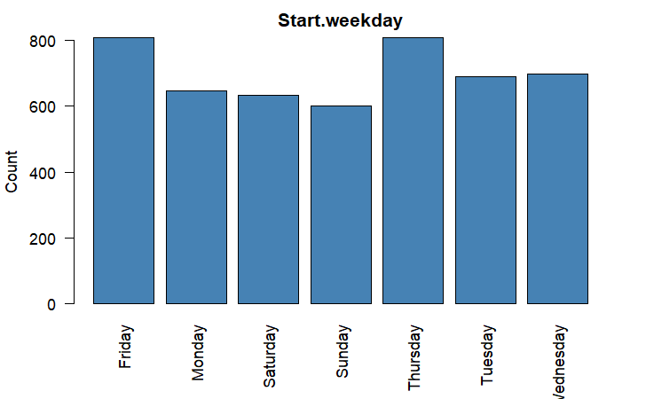

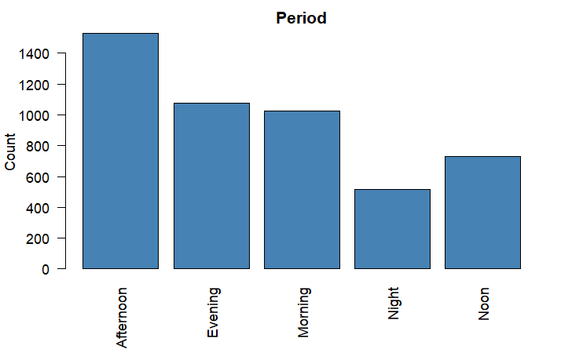

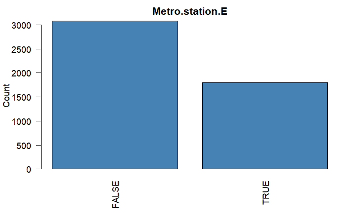

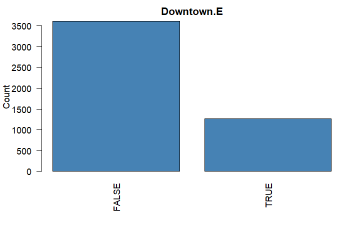

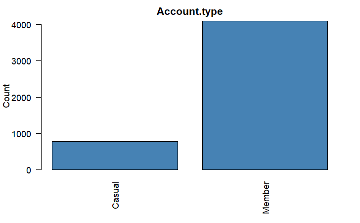

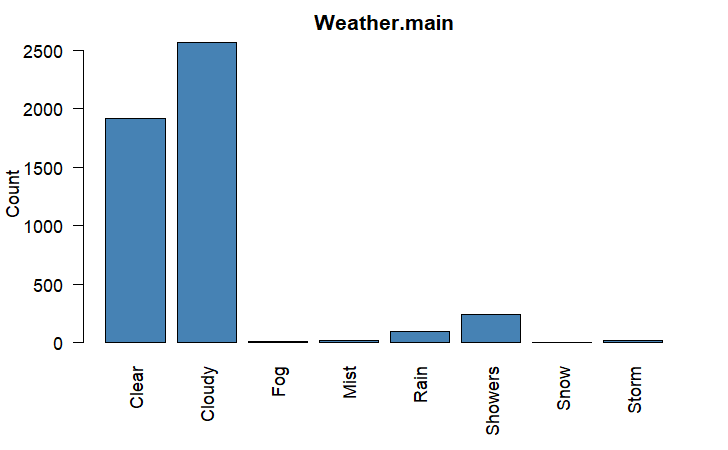

```r
for (i in 1:6) {
  plot(X2[,i], main=colnames(X2)[i],
       ylab = "Count", col="steelblue", las = 2)
  }
```

We are now ready to perform MCA

```r
?MCA
```

We use the MCA function of the FactoMineR package and we specify the number of dimensions to keep in the final results by means of the parameter ncp.

```r
bicing_mca = MCA(X2, ncp=10, quali.sup = 7,  quanti.sup=8, level.ventil=0.01, graph = FALSE)
```

## Questions

*What is the number of dimensions that this MCA generates? What does this value equal?*

```r
# Let's visualize the eigenvalues
bicing_mca$eig
```

```
       eigenvalue percentage of variance cumulative percentage of variance
dim 1   0.2290007               8.587527                          8.587527
dim 2   0.2003836               7.514386                         16.101913
dim 3   0.1955062               7.331482                         23.433395
dim 4   0.1804279               6.766046                         30.199442
dim 5   0.1752589               6.572209                         36.771650
dim 6   0.1719316               6.447434                         43.219085
dim 7   0.1681169               6.304385                         49.523470
dim 8   0.1670738               6.265267                         55.788736
dim 9   0.1644646               6.167424                         61.956160
dim 10  0.1620429               6.076607                         68.032768
dim 11  0.1582666               5.934997                         73.967764
dim 12  0.1541816               5.781812                         79.749576
dim 13  0.1502374               5.633904                         85.383480
dim 14  0.1333692               5.001345                         90.384825
dim 15  0.1320199               4.950745                         95.335570
dim 16  0.1243848               4.664430                        100.000000
```

MCA generates 16 dimensions which all together explain 100% of the variance of the original data.

We know that the number of dimensions generated by MCA is given by $K - J$, where $K$ represents the total number of categories of the active categorical variables, while $J$ represents the number of active categorical variables.

In our case $J$ is equal to 6, while $K$ is equal to the total sum of the categories of each active categorical variable:

```r
unique_count = c()
for(col in 1:(length(colnames(X2)) - 2)){
  unique_count = c(unique_count, length(unique(X2[,colnames(X2)[col]])))
}
sum(unique_count)
```

```
[1] 26
```

For the rest of the exploitation, we will only keep the 10 first dimensions as we specified when computing MCA (through the `ncp` argument).

### Visualization and Interpretation

Let’s now analyze the insight of the MCA computation.

### Plots

**Interpret the first factorial plane (dimensions 1 and 2) by means of variables and categories**

Let’s first interpret the variable categories plot on the first 2 dimensions (we use the ‘fviz_mca_var’ function of the factoextra package):

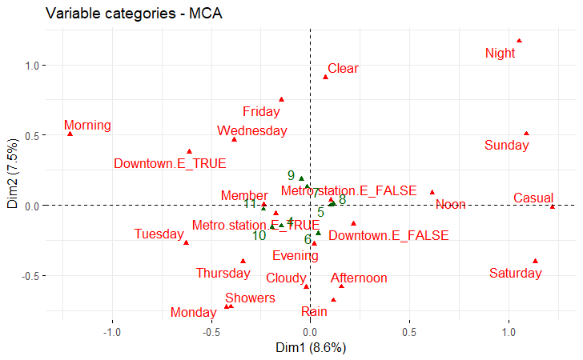

```r
fviz_mca_var(bicing_mca, repel = TRUE, ggtheme = theme_minimal())
```

On this plot, we can see how much variable categories are correlated to each others. For example, we can see a strong negative correlation between `Saturday` and `Morning` as being opposed compared to the origin of the plot. This means that a very few profiles were combining those two variables, if not none.  
**Contextualization:** A very few bike rentals were made on Satursday mornings, compared to other rentals.

Also, we can see that there is a relatively strong correlation between between `Friday` and `Wednesday` variables or between `Showers` and `Monday`.  
**Contextualization:** Profiles of bike rentals of Friday and Wednesday are pretty similar, which could be due to populations going out at night and renting bikes to do so (as it is less frequent to go out at the beginning of the week).

Let’s visualize the correlation between variables and MCA principal dimensions:

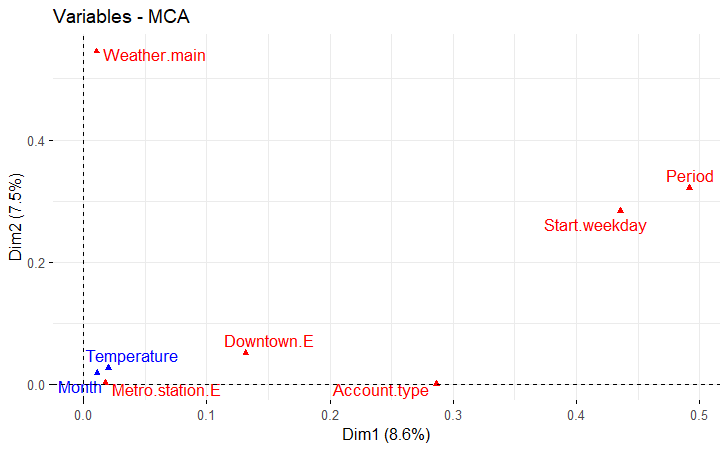

```r
# plot the correlations between variables and 1st factorial plane
fviz_mca_var(bicing_mca, choice="var", repel = TRUE, ggtheme = theme_minimal())
```

On this plot, we can see how each variables are correlating with the 2 first dimensions. For example, we can see that `Weather.main` is strongly correlated with the second dimension when the supplementary variable `Temperature` is having a low correlation with both dimensions, thus not having a strong relation on this dimension. Also, there are variables such as `Period` or `Start.weekday` which have a mixed correlation with both dimensions.

#### Choosing dimensions

Let’s display the bar plot of the percentage of variance explained by each component

We can see that the computed dimensions have all of them a relatively low portion of variation explanation (In order to not be biased during reading this plot, please pay attention to the y axis range):

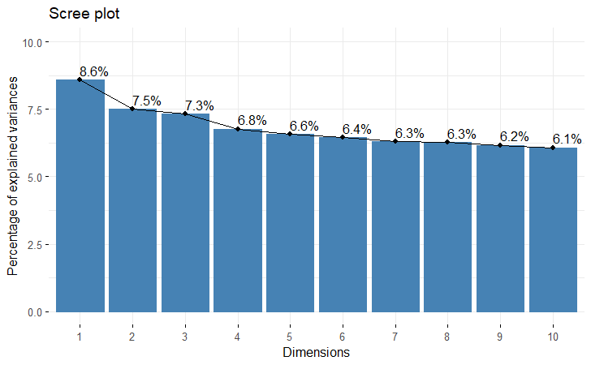

```r
fviz_screeplot(bicing_mca, addlabels = TRUE, ylim = c (0, 10))
```

**Which percentage of variability is explained by the first two dimensions?** For example, for the above interpretation of variables and categories, we used the two first dimensions. Even if they are the most explaining in terms of variance, they only account for 16% of variance in total.

We can print the eigenvalues and the variance explained by each dimension:

```r
bicing_mca$eig
```

```
       eigenvalue percentage of variance cumulative percentage of variance
dim 1   0.2290007               8.587527                          8.587527
dim 2   0.2003836               7.514386                         16.101913
dim 3   0.1955062               7.331482                         23.433395
dim 4   0.1804279               6.766046                         30.199442
dim 5   0.1752589               6.572209                         36.771650
dim 6   0.1719316               6.447434                         43.219085
dim 7   0.1681169               6.304385                         49.523470
dim 8   0.1670738               6.265267                         55.788736
dim 9   0.1644646               6.167424                         61.956160
dim 10  0.1620429               6.076607                         68.032768
dim 11  0.1582666               5.934997                         73.967764
dim 12  0.1541816               5.781812                         79.749576
dim 13  0.1502374               5.633904                         85.383480
dim 14  0.1333692               5.001345                         90.384825
dim 15  0.1320199               4.950745                         95.335570
dim 16  0.1243848               4.664430                        100.000000
```

Therefore, these dimensions (the first 2) are not so representative of the whole variance.

**Decide the number of significant dimensions that you retain.** The question is: how can we keep significant dimensions without loosing on representation quality (as too much dimension makes representation harder) ?

In order to decide the number of significant dimensions to retain, we know that we can use an empirical formula, which states that a good criteria is to interpret the axes of inertia above 1/**J** , where **J** is equal to the number of active categorical variables, which is 6 in our case

```r
sum(bicing_mca$eig[,1]>(1/6))
```

```
[1] 8
```

Therefore, according to the empirical formula we should keep the first 8 dimensions.

**Discuss which modalities contribute most to the first and second dimensions** Let’s show the bar plot of the contribution to the first dimension (Morning is first): > Please note that we will negate the input for each `rank` function uses in order to get descendant rankings and not the ascendant ranking that is offering the fuction by default.

```r
fviz_contrib (bicing_mca, choice="var", axes=1, top=10)
```

[output not shown]

And to the second dimension (Clear is first):

```r
fviz_contrib (bicing_mca, choice="var", axes=2, top=10)
```

[output not shown]

We can see that:  
* For the first dimension: we first note that variable categories have sparse rankings. It is mostly `Period` (with `Morning` 1st and `Night` 5th), `Account.type` (with Casual as 2nd) and `Start.weekday` (with `Saturday` 3rd and `Sunday` 4th) that are the top contributors to this dimension. * For the second dimension: the variable categories are less spreaded than in the first dimension. Top contributors are Weather (with `Clear` 1st and `Cloudy` 2nd) then `Period` (with `Night` 3rd and `Afternoon` 4th) and `Start.weekday` (Friday 5th and Monday 6th).

It is normal that there is not that much correlation beween those two dimensions as the goal of computing those dimensions is to maximize variance explaination thus reducing correlation at maximum (or having those two dimensions would be useless as giving the same insights). Here is the correlation score (-0.17) which we expected to be low:

```r
cor(bicing_mca$var$contrib[,1:2])
```

[output not shown]

### What about variables representation ?

Above we interpreted the contribution of each variables in the dimensions using the eigenvalue decomposition and others. But how can we ensure that each variable are well represented in those dimensions ?  
This is where the `cos2` score becomes relevant: it measures each variables’ representation, as can be seen on the below plot (for dim1 and 2):

```r
fviz_mca_var(bicing_mca, col.var = "cos2",
             gradient.cols = c("#00AFBB", "#E7B800", "#FC4E07"),
             repel = TRUE,
             ggtheme = theme_minimal())
```

[output not shown]

The more the cos2 score is higher (red), the more the variable is being represented in the dimension.

**For the other variables, identify the dimensions where the categories of “Metro.station.E” and “Downtown.E” are best represented.** To do so, as before, we will use the `rank` function to find dimensions representing the most these two variables `Metro.station.E` and `Downtown.E`. As can be seen below, we can just keep the cos2 score of `Metro.station.E_TRUE` and `Downtown.E_TRUE` as it is the same for the whole variable:

```r
bicing_mca$var$cos2[13:16,]
```

[output not shown]

Therefore, here are the rankings for `Metro.station.E`:

```r
rank(-bicing_mca$var$cos2[13,])
```

```
 Dim 1  Dim 2  Dim 3  Dim 4  Dim 5  Dim 6  Dim 7  Dim 8  Dim 9 Dim 10
     6     10      9      3      5      7      1      8      4      2
```

```r
bicing_mca$var$cos2[13,]
```

```
      Dim 1       Dim 2       Dim 3       Dim 4       Dim 5       Dim 6       Dim 7       Dim 8       Dim 9      Dim 10
0.017764665 0.002162686 0.003422187 0.090163355 0.070066773 0.013787147 0.318750852 0.010305906 0.089748041 0.236542218
```

And the same for `Downtown.E`:

```r
rank(-bicing_mca$var$cos2[15,])
```

```
 Dim 1  Dim 2  Dim 3  Dim 4  Dim 5  Dim 6  Dim 7  Dim 8  Dim 9 Dim 10
     2      3      1      4      8      7      5      6      9     10
```

```r
bicing_mca$var$cos2[15,]
```

```
       Dim 1        Dim 2        Dim 3        Dim 4        Dim 5        Dim 6        Dim 7        Dim 8        Dim 9       Dim 10
0.1317916474 0.0506036982 0.3260216294 0.0354911149 0.0088793269 0.0135339342 0.0336927839 0.0235361477 0.0025798579 0.0002901973
```

### Supplementary variables

**Are the supplementary variables related to the principal axes? In which way?**

#### Supplementary quantitative variables

Let’s first analyze the `Temperature` correlations with the first 2 dimensions.

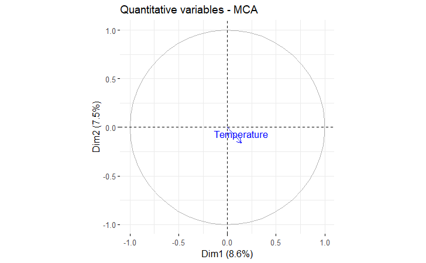

```r
fviz_mca_var(bicing_mca, choice = "quanti.sup", ggtheme = theme_minimal())
```

We can see that the two principal dimensions are not so influenced by the `Temperature` variables. We could also check if they are more for other dimensions:

```r
bicing_mca$quanti.sup
```

```
$coord
                Dim 1      Dim 2      Dim 3       Dim 4      Dim 5    Dim 6       Dim 7      Dim 8       Dim 9      Dim 10
Temperature 0.1431492 -0.1627847 0.09310506 -0.08535208 0.04303298 -0.16372 0.009084993 -0.0292639 -0.06212813 0.008375944
```

#### Supplementary qualitative variables

What about the `Month` variable ?

Let’s see the coordinates on the 1st factorial plane:

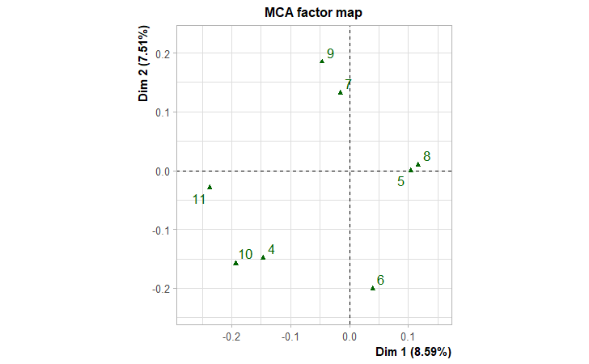

```r
plot.MCA(bicing_mca, invisible=c("ind", "var", "ind.sup", "quanti.sup"))
```

We can see the correlation of this supplementary variable with the 1st and the 2nd dimension:

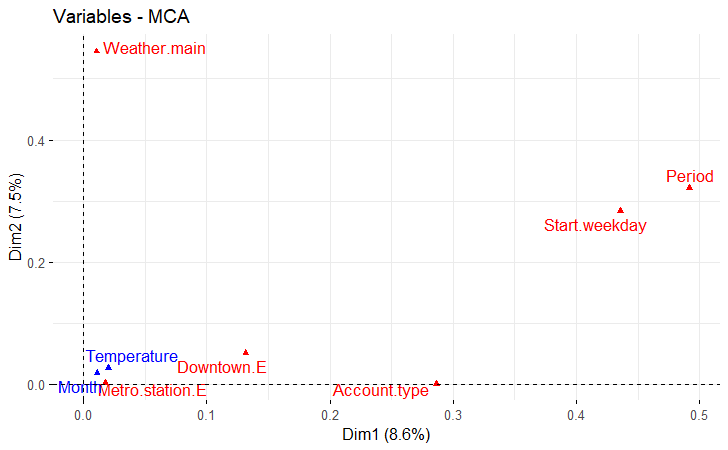

```r
# plot the correlations between variables and 1st factorial plane
fviz_mca_var(bicing_mca, choice="var", repel = TRUE, ggtheme = theme_minimal())
```

We can see that month is not strongly correlated with the first 2 dimensions.

We can investigate even more the results for this supplementary qualitative variable:

```r
bicing_mca$quali.sup
```

```
$coord
         Dim 1         Dim 2        Dim 3        Dim 4         Dim 5        Dim 6        Dim 7       Dim 8        Dim 9       Dim 10
4  -0.14682359 -0.1484743343 -0.106393645 -0.037104765  0.0832889325 -0.020255624  0.120482537 -0.01024910  0.075513545  0.192668202
5   0.10437250 -0.0001148016 -0.004149018  0.001359328  0.0796274099  0.012951637 -0.028799708 -0.01677152 -0.040351104 -0.073091747
6   0.03939383 -0.2007027810 -0.010567324  0.063915212 -0.0106245133  0.107405586 -0.001488671 -0.03267159 -0.018096952 -0.038052696
7  -0.01559531  0.1317650398  0.010088137 -0.068316632 -0.0619463791  0.028207709 -0.063546137  0.04837777 -0.002111458  0.003081463
8   0.11667505  0.0094008249  0.079433379  0.018035361 -0.0434532780 -0.115310068  0.029554843  0.05478621 -0.039412626  0.050727033
9  -0.04646309  0.1846161150 -0.063673194 -0.012437596  0.0000409662  0.009643915  0.054164008 -0.11635733  0.062140654  0.051680172
10 -0.19355643 -0.1581475427  0.023100241  0.008531309  0.0168345686 -0.021867532 -0.101505727  0.11773215 -0.032415878 -0.049241764
11 -0.23761276 -0.0287745060 -0.012675218  0.050042539  0.0671411974 -0.114408584  0.217269247 -0.07193080  0.187973863 -0.077834371

$cos2
          Dim 1        Dim 2        Dim 3        Dim 4        Dim 5        Dim 6        Dim 7        Dim 8        Dim 9       Dim 10
4  9.603535e-04 9.820695e-04 5.042789e-04 6.133365e-05 3.090395e-04 1.827809e-05 6.466774e-04 4.679623e-06 2.540324e-04 1.653711e-03
5  2.102511e-03 2.543676e-09 3.322437e-06 3.566271e-07 1.223746e-03 3.237542e-05 1.600819e-04 5.428886e-05 3.142512e-04 1.031105e-03
6  2.986125e-04 7.751008e-03 2.148728e-05 7.860676e-04 2.172048e-05 2.219756e-03 4.264310e-07 2.053960e-04 6.301767e-05 2.786264e-04
7  5.481476e-05 3.912999e-03 2.293672e-05 1.051870e-03 8.648509e-04 1.793267e-04 9.100970e-04 5.274739e-04 1.004788e-06 2.140046e-06
8  2.723284e-03 1.767945e-05 1.262243e-03 6.507086e-05 3.777304e-04 2.659937e-03 1.747407e-04 6.004535e-04 3.107475e-04 5.147730e-04
9  3.972771e-04 6.272153e-03 7.460891e-04 2.846756e-05 3.088366e-10 1.711529e-05 5.398822e-04 2.491523e-03 7.106063e-04 4.915020e-04
10 3.854853e-03 2.573461e-03 5.490674e-05 7.489003e-06 2.916061e-05 4.920307e-05 1.060166e-03 1.426208e-03 1.081205e-04 2.494939e-04
11 2.039127e-03 2.990339e-05 5.802506e-06 9.044476e-05 1.628107e-04 4.727396e-04 1.704909e-03 1.868678e-04 1.276144e-03 2.188001e-04

$v.test
        Dim 1        Dim 2      Dim 3       Dim 4        Dim 5      Dim 6      Dim 7      Dim 8       Dim 9     Dim 10
4  -2.1639510 -2.188280376 -1.5680766 -0.54686642  1.227549107 -0.2985363  1.7757249 -0.1510558  1.11295202  2.8396291
5   3.2018499 -0.003521785 -0.1272800  0.04170029  2.442741417  0.3973192 -0.8834928 -0.5145022 -1.23785657 -2.2422460
6   1.2066625 -6.147675717 -0.3236850  1.95777058 -0.325436758  3.2899131 -0.0455991 -1.0007552 -0.55432313 -1.1655824
7  -0.5169882  4.368041256  0.3344241 -2.26471200 -2.053536659  0.9350920 -2.1065690  1.6037341 -0.06999532  0.1021512
8   3.6439993  0.293606884  2.4808660  0.56328102 -1.357134265 -3.6013680  0.9230579  1.7110848 -1.23093649  1.5843084
9  -1.3918057  5.530191406 -1.9073359 -0.37256925  0.001227146  0.2888843  1.6224874 -3.4854937  1.86142857  1.5480839
10 -4.3354659 -3.542343121  0.5174218  0.19109260  0.377077110 -0.4898103 -2.2736244  2.6370797 -0.72608249 -1.1029651
11 -3.1532177 -0.381849377 -0.1682053  0.66408481  0.890990949 -1.5182484  2.8832511 -0.9545509  2.49448948 -1.0328937

$eta2
           Dim 1    Dim 2       Dim 3       Dim 4       Dim 5       Dim 6       Dim 7       Dim 8      Dim 9      Dim 10
Month 0.01104502 0.018308 0.002259635 0.001748991 0.002543965 0.004784387 0.004704667 0.004730839 0.00274908 0.003964347
```

**General conclusion about supplementary variables**  
Whether it is quantitative or qualitative variables, we can see that they are not really related to principal dimensions Dim1 and Dim2 (but can be with other dimensions, as explained above).